# PC GP03 05 C/NC - maintain 37 - 38 deg

## Percussion (2019-05-22)

- 3 hits at ? deg:
1. Hit 1: 5.9 atm, ICP from 12 to 24 at 14:41 pm
2. Hit 2: 4.8 atm, ICP from 20 to 41 at 14:43 pm
3. Hit 3: 6.9 atm, ICP from 29 to 49 at 14:44 pm

Study ended at 11:00 am (next day - after 20h scan).

## Cooling

Started at 14:50 pm.  
Brain temperature was 37.4deg, maintained at 37 but stayed at 38 (device malfunctioned).

## Cooling set up

1st target = -15 deg (VT output air)  
Flow rate = 60 SLPM  
2nd target = 37 deg (brain temp to cool down to)  
Maintenance time = 960 min once brain reached 33 deg  
3rd target temperature = 38 deg (rewarm target)  
Rewarm rate = 0.25 deg/h

#### Description

In maintenance mode At 5:52 pm the VT tube output temp. reached -15.1 deg and flow rate at 60 lpm and fraction ration at 60% brain temp at 37 deg

In maintenance mode At 6:05 pm the output temp back to -11.8 deg and flow rate at 60 lpm and fraction ration at 60%  
Brain temperature at 36.8 deg

In maintenance mode Starting at 6:45pm brain temperature kept increasing from 37.4 to 38.5 at 7:30 pm while the VT is max out at -14.6 deg FR 47% PSI 35

At 9:32 pm or thereabout, the cool device in maintenance mode seemed to lose air flow. at that time the brain temperature was 38.4C. Power off and power on to reset the device. Because the brain temperature was 38.4C above the target temperature 37C. the device remain in the cooling mode, the target temp for VT output air was -15.8c /72fr decrease to 32% psi 39 50 lpm but VT output was -13.9C (brfore the reset the output temp was -14.6C).

From 9:32 pm onwards the VT output air temp was -14.5C.

[output not shown]

## Surgivet and cooling data

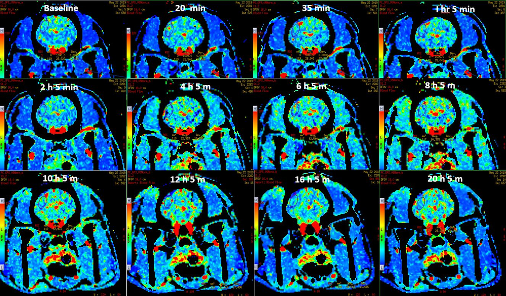

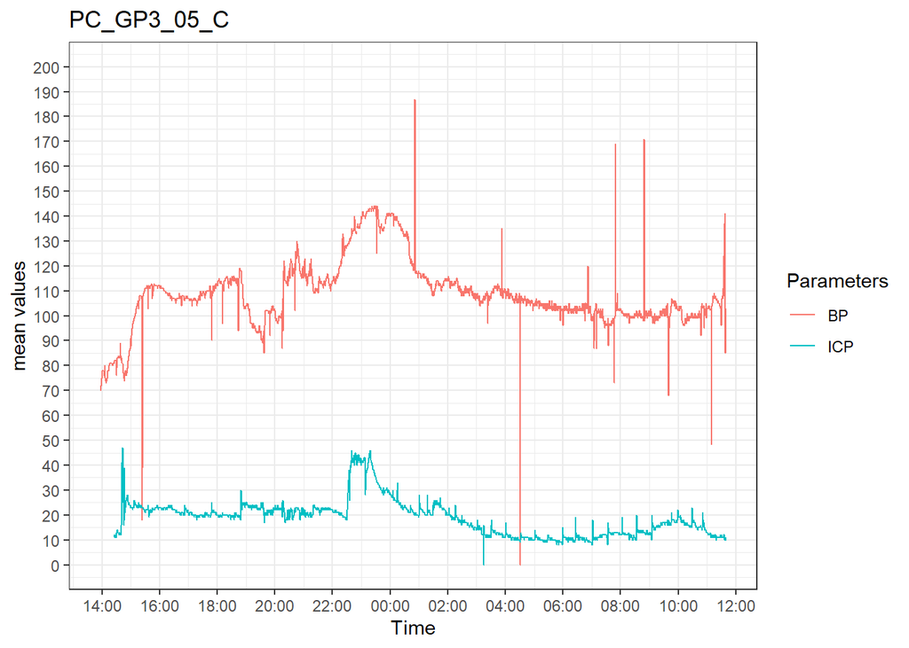

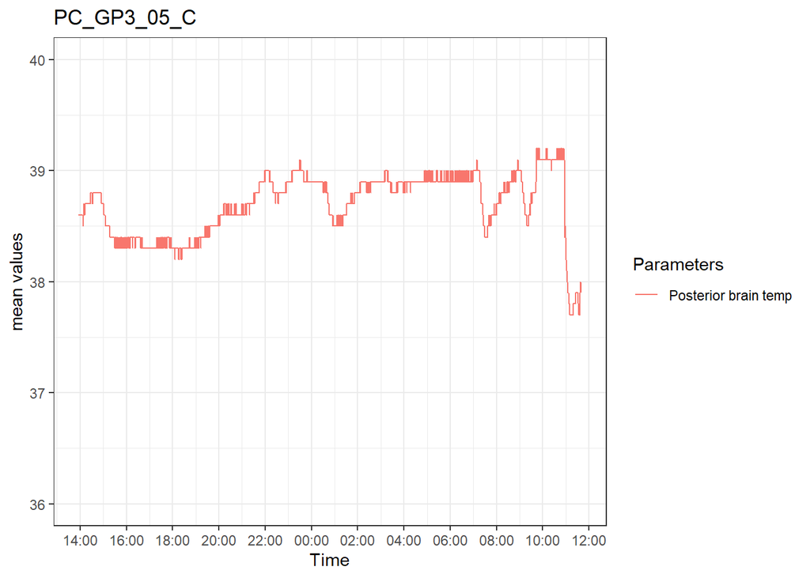

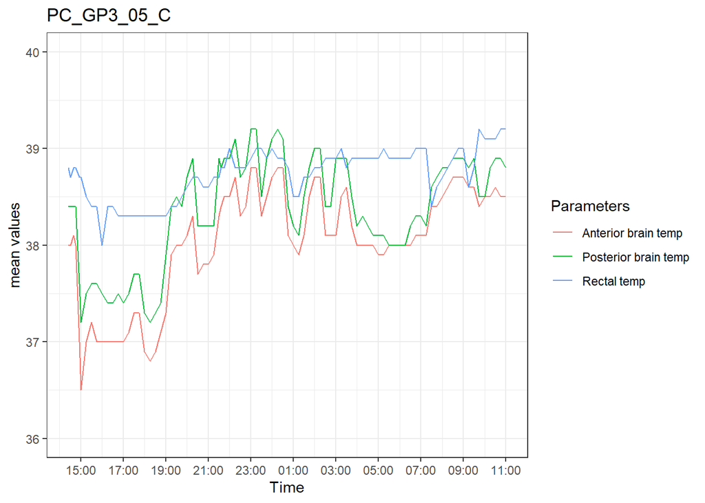

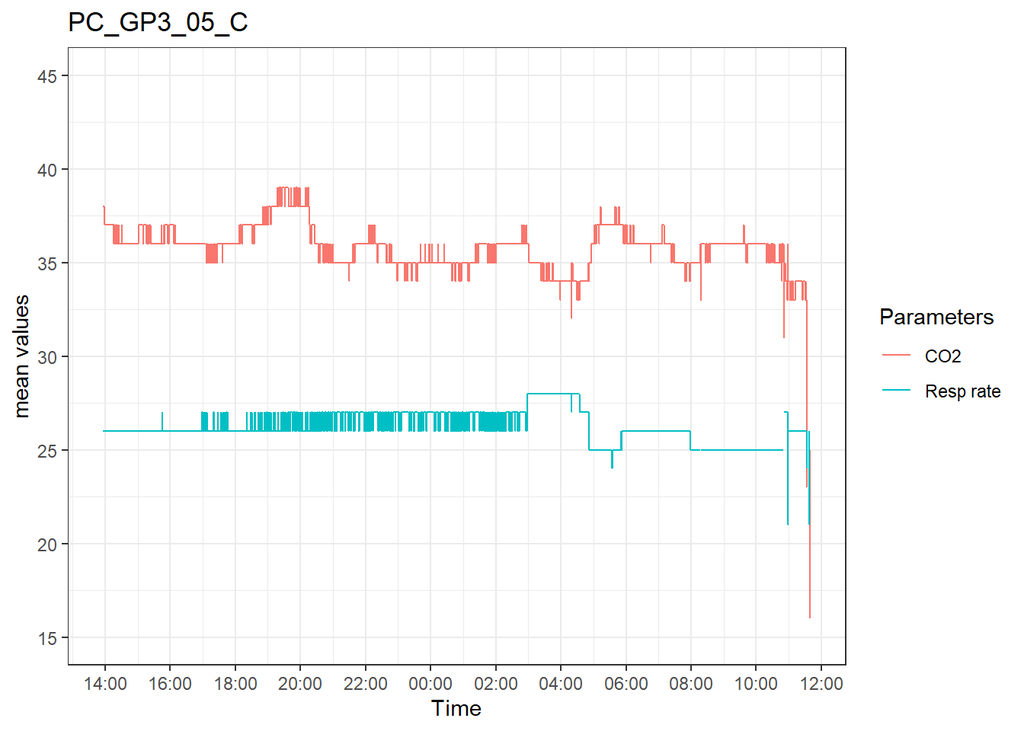

## Missing cooling unit record